# Lecture 2 IC

# 4 **Query 4 — JOIN: Daily Users + Daily Purchases**

[figure not shown]

```sql
WITH daily_users AS (
  SELECT
    event_date,
    COUNT(DISTINCT user_pseudo_id) AS users
  FROM `bigquery-public-data.ga4_obfuscated_sample_ecommerce.events_*`
  WHERE _TABLE_SUFFIX BETWEEN '20201201' AND '20201231'
  GROUP BY event_date
),

daily_purchases AS (
  SELECT
    event_date,
    COUNT(*) AS purchases
  FROM `bigquery-public-data.ga4_obfuscated_sample_ecommerce.events_*`
  WHERE event_name = 'purchase'
    AND _TABLE_SUFFIX BETWEEN '20201201' AND '20201231'
  GROUP BY event_date
)

SELECT
  u.event_date,
  u.users,
  IFNULL(p.purchases, 0) AS purchases
FROM daily_users u
LEFT JOIN daily_purchases p
  ON u.event_date = p.event_date
ORDER BY u.event_date;
```

### 4.0.1 **Explanation**

This query joins two aggregated datasets: daily user counts and daily purchase counts. A LEFT JOIN ensures that days with zero purchases still appear in the results.

# 5 **Query 5 — Window Functions + QUALIFY**

## 5.1 **Part A — Top 3 Events per Day**

```sql
WITH daily_event_counts AS (
  SELECT
    event_date,
    event_name,
    COUNT(*) AS events
  FROM `bigquery-public-data.ga4_obfuscated_sample_ecommerce.events_*`
  WHERE _TABLE_SUFFIX BETWEEN '20201201' AND '20201207'
  GROUP BY event_date, event_name
)

SELECT
  event_date,
  event_name,
  events,
  RANK() OVER (PARTITION BY event_date ORDER BY events DESC) AS rnk
FROM daily_event_counts
QUALIFY rnk <= 3
ORDER BY event_date, rnk;
```

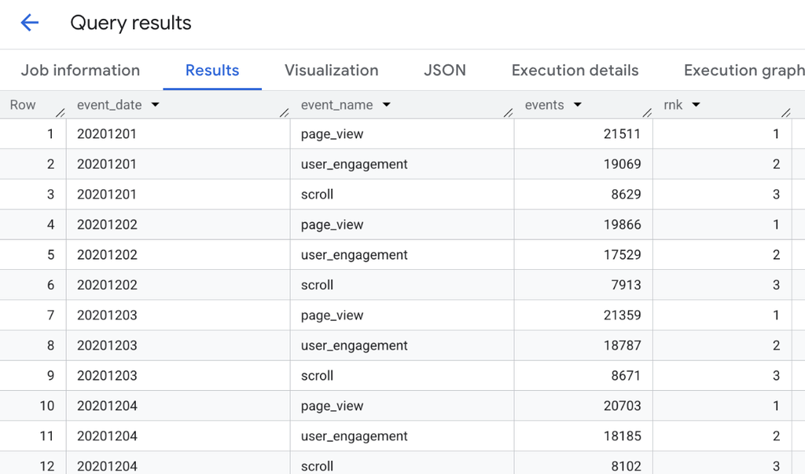

### 5.1.1 **Explanation**

This query ranks event types within each day using a window function. QUALIFY filters the results to only keep the top three events per day.

## 5.2 **Part B — Rolling 7-Day Average**

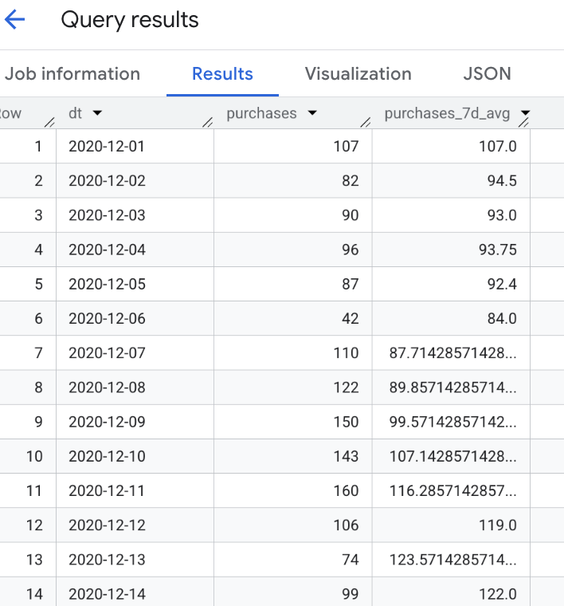

```sql
WITH daily_purchases AS (
  SELECT
    PARSE_DATE('%Y%m%d', event_date) AS dt,
    COUNT(*) AS purchases
  FROM `bigquery-public-data.ga4_obfuscated_sample_ecommerce.events_*`
  WHERE event_name = 'purchase'
    AND _TABLE_SUFFIX BETWEEN '20201201' AND '20201231'
  GROUP BY dt
)

SELECT
  dt,
  purchases,
  AVG(purchases) OVER (
    ORDER BY dt
    ROWS BETWEEN 6 PRECEDING AND CURRENT ROW
  ) AS purchases_7d_avg
FROM daily_purchases
ORDER BY dt;
```

### 5.2.1 **Explanation**

This query calculates a rolling 7-day average of purchases using a window function. It allows trend analysis without collapsing the dataset into a single row.

# 6 **Query 6 — Approximate Function**

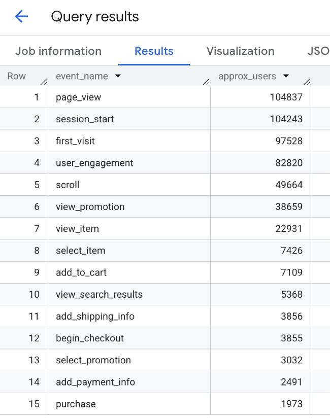

```sql
SELECT
  event_name,
  APPROX_COUNT_DISTINCT(user_pseudo_id) AS approx_users
FROM `bigquery-public-data.ga4_obfuscated_sample_ecommerce.events_*`
WHERE _TABLE_SUFFIX BETWEEN '20201201' AND '20201231'
GROUP BY event_name
ORDER BY approx_users DESC
LIMIT 15;
```

### 6.0.1 **Explanation**

This query uses APPROX_COUNT_DISTINCT to estimate unique users per event type. It is faster and more efficient for large datasets while still providing close estimates